**ids-pdl05-hwk.ipynb**: This Jupyter notebook is provided by Joachim Vogt for the *Python Data Lab* of the module *Introduction to Data Science* offered in Fall 2022 at Jacobs University Bremen. Module instructors are Hilke Brockmann, Adalbert Wilhelm, and Joachim Vogt. Jupyter notebooks and other learning resources are available from a dedicated *module platform*.

# Homework assignments: Matplotlib basics

The homework assignments in this notebook supplement the tutorial *Matplotlib basics*.

- Solve the assignments according to the instructions.
- Upload the completed notebook to the module platform.
- Do not forget to enter your name in the markdown cell below.

The homework set carries a total of 20 points. Square brackets in the assignment titles specify individual point contributions.

## Name: Joshua Law

## Preparation

Import the NumPy module in the standard way (prefix `np`). From the matplotlib library import the package `pyplot` using the standard abbreviation `plt`.

```python
import numpy as np
import matplotlib.pyplot as plt
```

On the module platform you find data files of the form `pdl05dat_SID.txt` where `SID` is a three-digit student ID, containing the data for the assignments below.

- Identify the file `pdl05dat_SID.txt` with your personal student ID `SID`, then upload it to the working directory, i.e., the folder where this Jupyter notebook resides.
- The data file `pdl05dat_100.txt` and its solution files `pdl05num_100.txt`, `pdl05lin_100.svg`, `pdl05mul_100.svg`, and `pdl05img_100.png` are provided to demonstrate the assignment. Upload the files also to the working directory.

## Assignment: Loading numerical data from regular text files [5]

```python
### Test the code with SID=100, then use your personal student ID for the final run of the notebook.
SID = 100
### Using np.loadtxt(), load the content of pdl05dat_SID.txt into the matrix data.
data = np.loadtxt("pdl05dat_"+str(SID)+".txt")
### Construct a one-dimensional array rmean containing the row means (obtained by averaging along axis=0).
rmean = data.mean(axis=0)
### Compute and print the maximum and the corresponding index of rmean.
print("Maximum of row means : ",np.max(rmean))
print("Index at maximum     : ",np.argmax(rmean))
### Compute and print the minimum and the corresponding index of rmean.
print("Minimum of row means : ",np.min(rmean))
print("Index at minimum     : ",np.argmin(rmean))
```

```
Maximum of row means :  245.26829268292684
Index at maximum     :  30
Minimum of row means :  79.6829268292683
Index at minimum     :  15
```

Here is the output that you should obtain for `SID = 100`, i.e., for the sample data file `pdl05dat_100.txt`.

```python
f = open('pdl05num_100.txt','r')
num100 = f.read()
f.close()
print(num100)
```

```
Student-ID: 100

Maximum of row means : 245.268293
Index at maximum     :  30

Minimum of row means : 79.682927
Index at minimum     :  15
```

## Assignment: Line plots [6]

Using the data from the file `pdl05dat_SID.txt` where `SID` is your personal three-digit student ID, and the object-oriented approach to plotting in matplotlib, create a diagram with the same format as the following sample graphics (for `SID=100`). The first three lines display rows of the data matrix at indices 10,20,30. As before, the row mean (fourth line) results from averaging along `axis=0`. Store the graphics in svg format as `pdl05lin_SID.svg`.

[figure not shown]

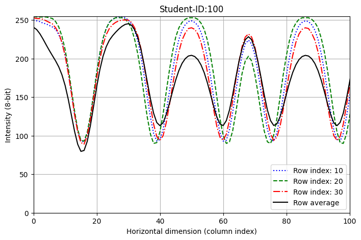

```python
### Test the code with SID=100, then use your personal student ID for the final run of the notebook.
SID = 100
### Create new figure and axis objects with figsize=(8,5).
fig,axs = plt.subplots(figsize=(8,5))
### Plot data vectors for row indices 10,20,30.
plt.plot(data[10],'b:',label="Row index: 10")
plt.plot(data[20],'g--',label= "Row index: 20")
plt.plot(data[30],'r-.',label="Row index: 30")
### Compute and plot the row mean.
plt.plot(rmean,'black',label="Row average")
### Add plot title and the axes annotations.
plt.title("Student-ID:"+str(SID))
plt.xlabel("Horizontal dimension (column index)")
plt.ylabel("Intensity (8-bit)")
### Set limits for coordinate axes.
plt.xlim(0,100)
plt.ylim(0,255)
### Add legend in lower right corner.

plt.legend(loc='lower right')
### Add coordinate coordinate grid.
plt.grid()
### After testing the code with SID=100, save the figure for your personal SID in svg format.
fig.savefig("pdl05lin_"+str(SID)+".svg")
```

## Assignment: Multiple plots in one diagram [6]

Using the data from the file `pdl05dat_SID.txt` where `SID` is your personal three-digit student ID, and the object-oriented approach to plotting in matplotlib, create a diagram with the same format as the following sample graphics (for `SID=100`). The first three panels display rows of the data matrix at indices 10,20,30. As before, the row mean (fourth panel) results from averaging along `axis=0`. Store the graphics in svg format as `pdl05mul_SID.svg`.

[figure not shown]

[figure not shown]

```python
### Test the code with SID=100, then use your personal student ID for the final run of the notebook.
SID = 100
sidstr = "(student-ID: " + str(SID)+")"
### Create new (2,2) figure and axes objects with figsize=(10,7).
fig,axs = plt.subplots(2,2,figsize=(10,7))
### Create plot at the [0,0] position with title, y-axis annotation, and proper limits.a
axs[0][0].plot(data[10],"b:")
axs[0][0].set_xlim(0,100)
axs[0][0].set_ylim(0,255)
axs[0][0].set_ylabel("Intensity (8-bit)")
axs[0][0].set_title("Row index: 10 "+sidstr)
### Create plot at the [0,1] position with title and proper limits.
axs[0][1].plot(data[20],"g--")
axs[0][1].set_xlim(0,100)
axs[0][1].set_ylim(0,255)
axs[0][1].set_title("Row index: 10 "+sidstr)
### Create plot at the [1,0] position with title, x-axis and y-axis annotations, and proper limits.
axs[1][0].plot(data[30],"r-.")
axs[1][0].set_xlim(0,100)
axs[1][0].set_ylim(0,255)
axs[1][0].set_ylabel("Intensity (8-bit)")
axs[1][0].set_xlabel("Horizontal dimension (column index)")
axs[1][0].set_title("Row index: 10 "+sidstr)
### Create plot at the [1,1] position with title, x-axis annotation, and proper limits.
axs[1][1].plot(rmean,"black")
axs[1][1].set_xlim(0,100)
axs[1][1].set_ylim(0,255)
axs[1][1].set_xlabel("Horizontal dimension (column index)")
axs[1][1].set_title("Row index: 10 "+sidstr)
### After testing the code with SID=100, save the figure for your personal SID in svg format.
fig.savefig("pdl05mul_"+str(SID)+".svg")
```

## Assignment: Displaying digital images [3]

Using the data from the file `pdl05dat_SID.txt` where `SID` is your personal three-digit student ID, and the MATLAB-style approach to plotting in matplotlib, create a diagram with the same format as the following sample graphics (for `SID=100`). Store the graphics in png format as `pdl05img_SID.png`.

[figure not shown]

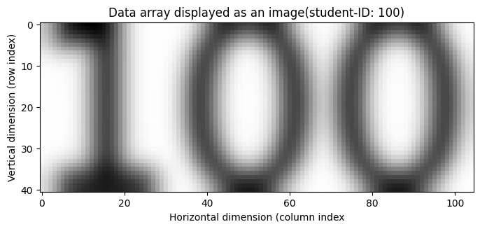

```python
### Test the code with SID=100, then use your personal student ID for the final run of the notebook.
SID = 100
### Create new figure object  with figsize=(8,5) and dpi=100.
plt.figure(figsize=(8,5),dpi=100)
### Plot the data matrix as a figure using the grayscale color map.
plt.imshow(data,cmap ="gray")
### Add title and axes annotations.
plt.title("Data array displayed as an image"+sidstr)
plt.xlabel("Horizontal dimension (column index")
plt.ylabel("Vertical dimension (row index)")
### After testing the code with SID=100, save the figure for your personal SID in png format.
fig.savefig("pdl05img_"+str(SID)+".png")
```